# Hooplytics Powered by Python

**Author:** Chris Campbell  
**Stack:** `nba_api` · `pandas` · `scikit-learn` · `seaborn` · `plotly`  
**Python:** 3.11+

`hooplytics` is the Python port of hooplyticsR. It analyzes NBA player performance using descriptive statistics, distributional visualizations, and supervised machine-learning models trained on historical box scores.

This notebook is organized as a narrative report:

1. **Setup & data ingestion** — pull per-game logs from the official NBA Stats API.
2. **Player statistics** — averages, standard deviations, and a fantasy score.
3. **Performance visualizations** — faceted histograms, KDEs, and an interactive radar.
4. **Predictive modeling** — kNN and Random Forest regressors with cross-validated tuning.
5. **Fantasy decisions** — combine projections with model predictions to produce More/Less calls.

## 1. Setup

We'll fetch each player's regular-season game logs season-by-season via [`nba_api`](https://github.com/swar/nba_api) and cache results to disk so re-runs don't hit the network.

```
✅ All packages present.
```

```
Python 3.14.3  |  pandas 3.0.2  |  numpy 2.4.4
```

### 1.1 Configure your roster

Run the cell below to launch an interactive **roster builder** powered by `ipywidgets` — works in VS Code, JupyterLab, and Google Colab.

**How to use it:**

1. **Pick a season range.** Adjust the *Start year* and *End year* boxes (NBA seasons span two calendar years — *Start year* is the year games tip off, *End year* is the year the season concludes. So `2024 → 2026` covers `2024-25` and `2025-26`; `2025 → 2026` covers only `2025-26`). Default is `2024 → 2026`.
2. **Add players.** Click in the **Add player** box and start typing — the dropdown filters live against every active NBA player. Pick from the menu (or type a full name) and click **Add**. Repeat for every player you want to analyze. The default 6-player roster (LeBron, KD, Wemby, SGA, Chet Holmgren, Ausar Thompson) is pre-loaded — click **Remove** on any row to drop it.
3. **Review projections.** If `ODDS_API_KEY` is set, today's live sportsbook lines are automatically filled in for `points`, `rebounds`, `assists`, and `threepm` wherever available. Otherwise, sensible defaults are shown. Edit any value before clicking Done.
4. **Click ✅ Done — Build roster.** This locks in `ROSTER`, `SEASONS`, `CURRENT`, and `PLAYERS` for the rest of the notebook. Then run §1.2 onward.

> 💡 5-game averages are **auto-derived** from game logs — no manual updates needed. Widget projections are only used in §5 when no live sportsbook line is available.

```
  Odds API: 8 NBA game(s) on the schedule (this will use ~32 quota credits)
  Odds API quota: 19968 remaining (used 32, this call cost 4)
  Odds API: cached 8 event(s) to nba_player_props_2026-04-24.json
  Odds API: 23 player prop line(s) matched for 6 roster player(s)
```

1.1 — Build your roster

| Player | Points | Fantasy | PRA | 3PM | Assists |
| --- | --- | --- | --- | --- | --- |
| LeBron James | ✅ 23.5 | 41.5 | 34.0 | ✅ 1.5 | ✅ 8.5 |
| Kevin Durant | ✅ 23.5 | 42.0 | 36.0 | ✅ 2.5 | ✅ 4.5 |
| Victor Wembanyama | ✅ 23.5 | 53.0 | 39.5 | ✅ 1.5 | ✅ 2.5 |
| Shai Gilgeous-Alexander | ✅ 31.5 | 50.0 | 41.0 | ✅ 1.5 | ✅ 7.0 |
| Chet Holmgren | ✅ 16.5 | 38.0 | 30.0 | ✅ 1.5 | ✅ 1.5 |
| Ausar Thompson | ✅ 8.5 | 34.0 | 26.0 | 0.5 | ✅ 2.5 |

✅ Roster locked in (6 players): LeBron James, Kevin Durant, Victor Wembanyama, Shai Gilgeous-Alexander, Chet Holmgren, Ausar Thompson — Seasons: 2024-25, 2025-26 — Next: run §1.2 to fetch game logs.

### 1.2 Fetch game logs

`PlayerGameLog` returns all regular-season box scores for one player-season. We loop over each (player, season), persist a Parquet cache per player, and concatenate.

```
Loading LeBron James  (2024-25, 2025-26) …
Loading Kevin Durant  (2024-25, 2025-26) …
Loading Victor Wembanyama  (2024-25, 2025-26) …
Loading Shai Gilgeous-Alexander  (2024-25, 2025-26) …
Loading Chet Holmgren  (2024-25, 2025-26) …
Loading Ausar Thompson  (2024-25, 2025-26) …

Loaded 757 games across 6 players and 2 season(s).
```

|  | SEASON_ID | Player_ID | Game_ID | game_date | MATCHUP | WL | min | fgm | fga | fg_pct | ... | fta_l30 | plus_minus_l5 | plus_minus_l10 | plus_minus_l30 | ast_per36_l30 | stl_per36_l30 | blk_per36_l30 | tov_per36_l30 | fga_per36_l30 | usg_proxy_l30 |
| --- | --- | --- | --- | --- | --- | --- | --- | --- | --- | --- | --- | --- | --- | --- | --- | --- | --- | --- | --- | --- | --- |
| 0 | 22024 | 1641709 | 0022400278 | 2024-11-25 | DET vs. TOR | W | 16 | 2 | 8 | 0.250 | ... | NaN | NaN | NaN | NaN | NaN | NaN | NaN | NaN | NaN | NaN |
| 1 | 22024 | 1641709 | 0022400293 | 2024-11-27 | DET @ MEM | L | 20 | 1 | 5 | 0.200 | ... | NaN | NaN | NaN | NaN | NaN | NaN | NaN | NaN | NaN | NaN |
| 2 | 22024 | 1641709 | 0022400045 | 2024-11-29 | DET @ IND | W | 12 | 1 | 5 | 0.200 | ... | NaN | -7.500000 | NaN | NaN | NaN | NaN | NaN | NaN | NaN | NaN |
| 3 | 22024 | 1641709 | 0022400301 | 2024-11-30 | DET vs. PHI | L | 14 | 4 | 5 | 0.800 | ... | NaN | -1.333333 | -1.333333 | NaN | NaN | NaN | NaN | NaN | NaN | NaN |
| 4 | 22024 | 1641709 | 0022400052 | 2024-12-03 | DET vs. MIL | L | 14 | 4 | 6 | 0.667 | ... | NaN | -2.000000 | -2.000000 | NaN | NaN | NaN | NaN | NaN | NaN | NaN |

5 rows × 71 columns

## 2. The tale of the tape

Time to put the roster on the scale. For every player we compute the **mean** (μ — the per-game ceiling you can plan around) and the **standard deviation** (σ — how wild the swings are between games).

> 📝 **The storyline callouts in §2 / §2.1 / §3.2 / §4.1 / §4.3 reference the original three players (LeBron, KD, Wemby).** The default roster now ships with three more (SGA, Chet Holmgren, Ausar Thompson) for tighter modeling — *tables and charts always reflect your live roster*; treat the prose as illustrative.

### The 2024-25 & 2025-26 storylines jumping off the page

**Wemby is breaking the spreadsheet.** About 24.7 PPG, about 11.3 RPG, and a casual 4.5 stocks (steals + blocks) per night — that stl+blk number is **more than 2× either veteran**. Add in a **+7.1 plus/minus** that leads the original trio (LeBron sits at +0.5, KD at +2.2) and you get a **53.9 fantasy score** that is basically a different sport from his peers.

**KD is the metronome.** 26.2 PPG on **53/44/83** splits — that's not a typo, the man is shooting 44% from three on real volume. The most consistent scorer among the original trio with a points CV around 0.26 (more on that in §2.1). When you need a bucket, he's the bet.

**LeBron at 41 is still the orchestrator.** A roster-leading **7.8 APG**, a 37.6-point PRA, and a hyper-balanced 23/7/8 stat line. The free-throw % (0.74) is a touch below his career average — small-sample noise on a player who has historically lived at 73-75%.

Per-player averages (μ) and standard deviations (σ)

|  | Player | Games | Points μ | Points σ | Rebounds μ | Rebounds σ | Assists μ | Assists σ | PRA μ | PRA σ | 3PM μ | 3PM σ | Stl+Blk μ | Stl+Blk σ | Turnovers μ | Turnovers σ | Fantasy μ | Fantasy σ |
| --- | --- | --- | --- | --- | --- | --- | --- | --- | --- | --- | --- | --- | --- | --- | --- | --- | --- | --- |
| 0 | Ausar Thompson | 132 | 9.960000 | 4.440000 | 5.460000 | 2.490000 | 2.740000 | 1.990000 | 18.170000 | 6.580000 | 0.130000 | 0.340000 | 2.670000 | 1.870000 | 1.440000 | 1.140000 | 27.210000 | 10.300000 |
| 1 | Chet Holmgren | 101 | 16.440000 | 6.550000 | 8.630000 | 3.580000 | 1.760000 | 1.260000 | 26.830000 | 8.820000 | 1.310000 | 1.360000 | 2.650000 | 1.980000 | 1.610000 | 1.330000 | 35.790000 | 12.190000 |
| 2 | Kevin Durant | 140 | 26.240000 | 6.750000 | 5.710000 | 2.310000 | 4.540000 | 2.440000 | 36.490000 | 7.860000 | 2.470000 | 1.440000 | 1.860000 | 1.530000 | 3.110000 | 1.950000 | 42.350000 | 10.040000 |
| 3 | LeBron James | 130 | 22.820000 | 7.040000 | 7.000000 | 3.410000 | 7.750000 | 2.970000 | 37.560000 | 9.410000 | 1.740000 | 1.540000 | 1.660000 | 1.200000 | 3.380000 | 2.020000 | 44.440000 | 11.210000 |
| 4 | Shai Gilgeous-Alexander | 144 | 31.950000 | 7.380000 | 4.660000 | 2.380000 | 6.490000 | 2.400000 | 43.100000 | 8.350000 | 1.930000 | 1.200000 | 2.470000 | 1.570000 | 2.320000 | 1.510000 | 52.350000 | 11.040000 |
| 5 | Victor Wembanyama | 110 | 24.690000 | 8.650000 | 11.290000 | 3.690000 | 3.340000 | 2.070000 | 39.320000 | 10.750000 | 2.400000 | 1.930000 | 4.460000 | 2.420000 | 2.760000 | 1.670000 | 53.870000 | 14.260000 |

### 2.1 Who can you actually trust on a Tuesday?

$$\text{CV} = \frac{\sigma}{\mu}$$

CV is unit-free, so we can rank consistency *across stats with very different scales* (e.g. points vs. blocks). **Lower = more reliable**. Think of it as the "is this guy gonna show up tonight?" index.

> 📝 The bullets below describe the original three players. The table itself always reflects whoever you put in §1.1.

What the numbers say about the original trio:

Coefficient of variation — lower = more consistent

| player | Points | Rebounds | Assists | PRA | 3PM | Stl+Blk | Turnovers | Fantasy |
| --- | --- | --- | --- | --- | --- | --- | --- | --- |
| Ausar Thompson | 0.446000 | 0.456000 | 0.727000 | 0.362000 | 2.611000 | 0.700000 | 0.793000 | 0.378000 |
| Chet Holmgren | 0.398000 | 0.415000 | 0.714000 | 0.329000 | 1.042000 | 0.745000 | 0.822000 | 0.341000 |
| Kevin Durant | 0.257000 | 0.403000 | 0.537000 | 0.215000 | 0.581000 | 0.824000 | 0.626000 | 0.237000 |
| LeBron James | 0.308000 | 0.487000 | 0.384000 | 0.250000 | 0.888000 | 0.721000 | 0.597000 | 0.252000 |
| Shai Gilgeous-Alexander | 0.231000 | 0.510000 | 0.370000 | 0.194000 | 0.621000 | 0.636000 | 0.652000 | 0.211000 |
| Victor Wembanyama | 0.350000 | 0.327000 | 0.621000 | 0.273000 | 0.805000 | 0.543000 | 0.604000 | 0.265000 |

## 3. Performance visualizations

We use four complementary views: faceted histograms with KDE overlays for shape, a side-by-side violin grid for distributional comparison, an interactive 10-game rolling-form line for trend, and a normalized radar for at-a-glance archetypes.

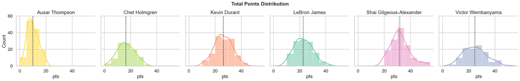

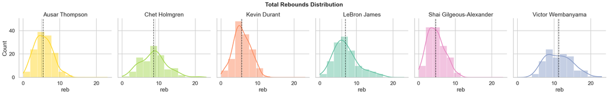

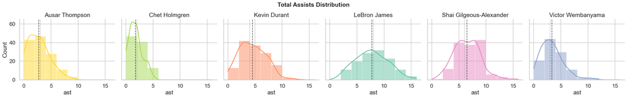

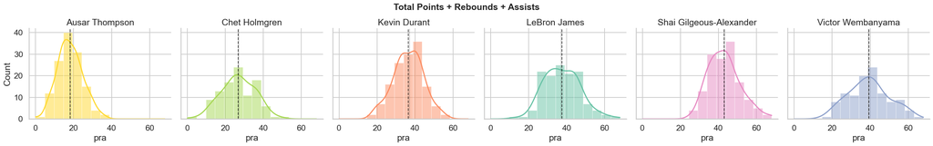

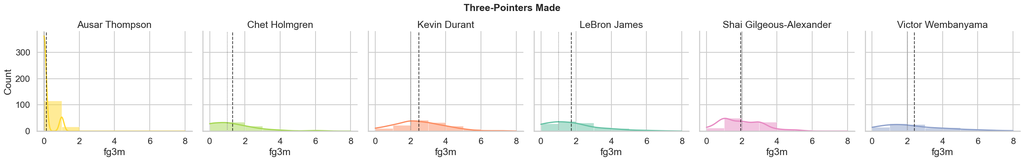

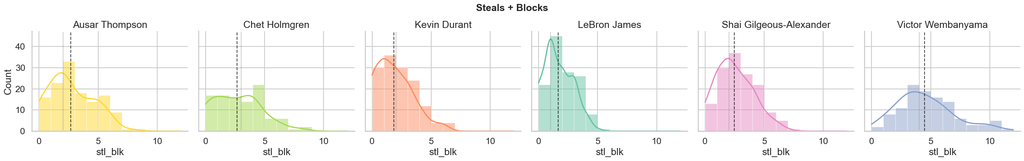

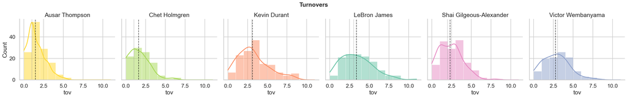

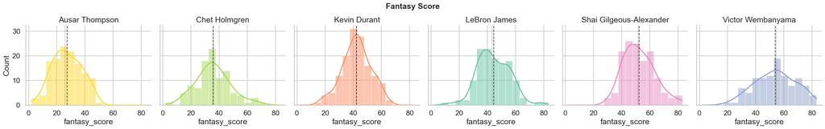

### 3.1 Side-by-side distribution comparison

A grid of violin + strip plots makes it easier to compare shapes across players for every core stat at once.

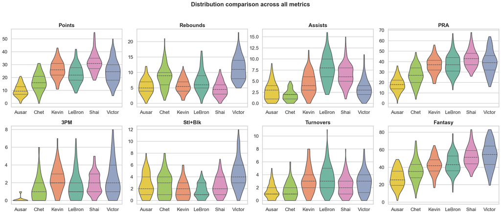

### 3.2 The rolling-form chart (a.k.a. "who's hot right now?")

A single game is noise. **A 10-game rolling mean** is the closest thing to seeing a player's vibes — injury returns, role changes, slumps, and heaters all pop out as smooth bumps and dips. Tap the legend to isolate a player, hover any line to read off the exact value.

> 📝 The "what to look for" bullets below are written for the **default roster**. The chart itself always reflects whoever you configured in §1.1.

For this season's run, watch for:

- **Wemby's line floating above the others** — the ~54-point fantasy mean isn't a one-game peak, it's the *floor* of his rolling stretch.
- **KD's line being almost a straight horizontal** — that's what a 0.237 fantasy CV looks like when you draw it.
- **LeBron's line sawtoothing in mid-40s territory** — vintage usage, modern load management.

[interactive chart not shown]

### 3.3 Player profile radar

Per-player averages are min-max normalized across the cohort so the radar shows *relative* strength on each axis.

[interactive chart not shown]

## 4. Predictive modeling

```
Train: 557  |  Test: 140
```

```
Training models (this can take a couple of minutes the first time)…
  points          cv RMSE = 2.134   best = {'model__n_neighbors': 4}
  rebounds        cv RMSE = 0.560   best = {'model__n_neighbors': 4}
  assists         cv RMSE = 2.374   best = {'model__alpha': 1.0}
  pra             cv RMSE = 2.946   best = {'model__n_neighbors': 7}
  threepm         cv RMSE = 0.287   best = {'model__n_neighbors': 3}
  stl_blk         cv RMSE = 1.751   best = {'model__alpha': 100.0}
  turnovers       cv RMSE = 1.621   best = {'model__alpha': 100.0}
  fantasy_score   cv RMSE = 4.270   best = {'model__max_depth': None, 'model__min_samples_leaf': 1, 'model__n_estimators': 400}
```

### 4.1 Held-out evaluation — the receipts

We score every model on the 20% test split using:

- **RMSE** — penalizes large misses; same units as the target.
- **MAE** — average absolute error; more robust to outliers.
- **R²** — proportion of variance explained. R² ≈ 1 is great, R² ≈ 0 means the model is no better than always predicting the mean, and **R² < 0 means worse than the mean baseline** — a flag that the chosen feature set is too thin.

#### What this run is telling us

> 📝 R² numbers below are from a representative run on the **default 6-player roster**. Your run will differ — sometimes by a lot, especially on the noisier targets. The *shape* of the takeaways (deterministic > context-dependent) holds across rosters.

Hold-out test performance

|  | model | target | kind | RMSE | MAE | R² |
| --- | --- | --- | --- | --- | --- | --- |
| 0 | assists | ast | ridge | 1.812000 | 1.413000 | 0.580000 |
| 1 | fantasy_score | fantasy_score | rf | 3.689000 | 2.929000 | 0.929000 |
| 2 | points | pts | knn | 1.852000 | 1.452000 | 0.965000 |
| 3 | pra | pra | knn | 2.756000 | 2.064000 | 0.946000 |
| 4 | rebounds | reb | knn | 0.544000 | 0.242000 | 0.980000 |
| 5 | stl_blk | stl_blk | ridge | 1.735000 | 1.435000 | 0.107000 |
| 6 | threepm | fg3m | knn | 0.317000 | 0.108000 | 0.958000 |
| 7 | turnovers | tov | ridge | 1.719000 | 1.357000 | 0.164000 |

### 4.2 Predicted vs. actual — eyeballing calibration

**How to read this grid.** There's one panel per model (8 total). For every game in the held-out 20% test set:

- The **x-axis** is the *actual* value the player put up that night (e.g. real points scored).
- The **y-axis** is what the model *predicted* before seeing that game.
- Each **dot is one game**, and its **color is the player** — see the shared legend at the bottom of the figure for the color → player mapping.
- The **dashed black diagonal** is the line $y = x$, i.e. a "perfect prediction" reference. Dots on the line = perfect; dots above = the model over-predicted; dots below = the model under-predicted.
- The **R² in each title** summarizes how tightly that cloud hugs the diagonal (1.0 = perfect, 0.0 = no better than always guessing the mean).

**Interactive controls.** This chart is now powered by Plotly:

- **Hover** any dot to see the player, model, the **specific game** (date and matchup), the actual value, and the predicted value.
- **Click** a player in the legend to hide/show their dots; **double-click** to isolate just that player across all 8 panels.
- **Drag** to box-zoom into a region of any panel; **double-click** the panel to reset the view.

**What to look for** (illustrative examples reference the **default roster**):

- **Tight diagonal cloud** (`points`, `rebounds`, `pra`) → trust the prediction at face value.
- **Funnel widening at the high end** → the model under-predicts ceiling games. Wemby 40-burgers and LeBron triple-double nights live in this region.
- **Horizontal banding** (`turnovers`, `stl_blk`) → the model is essentially predicting the league mean regardless of input. That's a feature-coverage problem, not a model problem.
- **Color clustering by player** → the model has learned "this is a Wemby-shaped row, output Wemby-shaped numbers" rather than a generalizable signal. With a small cohort that's expected; the fix is more roster diversity.

[interactive chart not shown]

### 4.3 Random-forest feature importances — what the model *actually* learned

If you see something different from the bars below, that's a signal worth investigating — it usually means a player's role is unusual relative to the league.

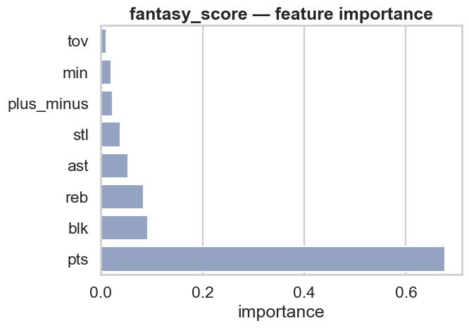

## 5. Fantasy decisions — More/Less engine

The More/Less engine combines three signals for each rostered player:

1. **Model prediction** — the trained estimator's output using the player's pregame-safe rolling features.
2. **Posted line** — from a live sportsbook via Odds API (when `ODDS_API_KEY` is set and the player has a game today) or your manually entered widget projection from §1.1.
3. **5-game average** — auto-derived from the data; anchors the prediction to recent form.

The `source` column shows which line was used. A 10% confidence margin is applied only to live sportsbook lines (you are competing against the book's vig); widget projections and season-average fallbacks are compared directly with no markup.

```
  Odds API: using cached lines from nba_player_props_2026-04-24.json (no API calls)
  Odds API: 23 player prop line(s) matched for 6 roster player(s)
✅  Live lines fetched: 23 player-prop rows.

=== LeBron James ===
```

Fantasy decisions — LeBron James

|  | model | prediction | line | source | 5-game avg | threshold | adj. threshold | decision |
| --- | --- | --- | --- | --- | --- | --- | --- | --- |
| 0 | points | 19.150000 | 23.500000 | live | 23.000000 | 23.450000 | 25.800000 | LESS ❌ |
| 1 | rebounds | 7.000000 | 6.500000 | live | 6.600000 | 6.510000 | 7.160000 | LESS ❌ |
| 2 | assists | 7.280000 | 8.500000 | live | 9.200000 | 8.570000 | 9.430000 | LESS ❌ |
| 3 | pra | 36.240000 | 34.000000 | widget | 38.800000 | 34.480000 | 34.480000 | MORE ✅ |
| 4 | threepm | 1.000000 | 1.500000 | live | 1.400000 | 1.490000 | 1.640000 | LESS ❌ |
| 5 | stl_blk | 1.810000 | 1.660000 | season avg | 2.600000 | 1.760000 | 1.760000 | MORE ✅ |
| 6 | turnovers | 3.290000 | 3.380000 | season avg | 3.200000 | 3.360000 | 3.360000 | LESS ❌ |
| 7 | fantasy_score | 40.800000 | 41.500000 | widget | 49.320000 | 42.280000 | 42.280000 | LESS ❌ |

```
=== Kevin Durant ===
```

Fantasy decisions — Kevin Durant

|  | model | prediction | line | source | 5-game avg | threshold | adj. threshold | decision |
| --- | --- | --- | --- | --- | --- | --- | --- | --- |
| 0 | points | 25.580000 | 23.500000 | live | 28.400000 | 23.990000 | 26.390000 | LESS ❌ |
| 1 | rebounds | 5.000000 | 5.500000 | live | 6.200000 | 5.570000 | 6.130000 | LESS ❌ |
| 2 | assists | 4.460000 | 4.500000 | live | 5.800000 | 4.630000 | 5.090000 | LESS ❌ |
| 3 | pra | 36.360000 | 36.000000 | widget | 40.400000 | 36.440000 | 36.440000 | LESS ❌ |
| 4 | threepm | 3.000000 | 2.500000 | live | 2.600000 | 2.510000 | 2.760000 | MORE ✅ |
| 5 | stl_blk | 1.960000 | 1.860000 | season avg | 1.600000 | 1.830000 | 1.830000 | MORE ✅ |
| 6 | turnovers | 2.940000 | 3.110000 | season avg | 2.800000 | 3.080000 | 3.080000 | LESS ❌ |
| 7 | fantasy_score | 42.850000 | 42.000000 | widget | 46.540000 | 42.450000 | 42.450000 | MORE ✅ |

```
=== Victor Wembanyama ===
```

Fantasy decisions — Victor Wembanyama

|  | model | prediction | line | source | 5-game avg | threshold | adj. threshold | decision |
| --- | --- | --- | --- | --- | --- | --- | --- | --- |
| 0 | points | 24.390000 | 23.500000 | live | 34.600000 | 24.610000 | 27.070000 | LESS ❌ |
| 1 | rebounds | 10.850000 | 11.500000 | live | 14.000000 | 11.750000 | 12.930000 | LESS ❌ |
| 2 | assists | 3.680000 | 2.500000 | live | 4.000000 | 2.650000 | 2.920000 | MORE ✅ |
| 3 | pra | 37.460000 | 39.500000 | widget | 52.600000 | 40.810000 | 40.810000 | LESS ❌ |
| 4 | threepm | 2.000000 | 1.500000 | live | 2.000000 | 1.550000 | 1.710000 | MORE ✅ |
| 5 | stl_blk | 4.230000 | 4.460000 | season avg | 3.800000 | 4.400000 | 4.400000 | LESS ❌ |
| 6 | turnovers | 2.510000 | 2.760000 | season avg | 1.400000 | 2.630000 | 2.630000 | LESS ❌ |
| 7 | fantasy_score | 52.370000 | 53.000000 | widget | 67.400000 | 54.440000 | 54.440000 | LESS ❌ |

```
=== Shai Gilgeous-Alexander ===
```

Fantasy decisions — Shai Gilgeous-Alexander

|  | model | prediction | line | source | 5-game avg | threshold | adj. threshold | decision |
| --- | --- | --- | --- | --- | --- | --- | --- | --- |
| 0 | points | 29.400000 | 31.500000 | live | 28.000000 | 31.150000 | 34.270000 | LESS ❌ |
| 1 | rebounds | 3.250000 | 4.500000 | live | 3.600000 | 4.410000 | 4.850000 | LESS ❌ |
| 2 | assists | 6.530000 | 7.000000 | live | 7.200000 | 7.020000 | 7.720000 | LESS ❌ |
| 3 | pra | 41.630000 | 41.000000 | widget | 38.800000 | 40.780000 | 40.780000 | MORE ✅ |
| 4 | threepm | 2.000000 | 1.500000 | live | 1.800000 | 1.530000 | 1.680000 | MORE ✅ |
| 5 | stl_blk | 2.360000 | 2.470000 | season avg | 1.400000 | 2.360000 | 2.360000 | MORE ✅ |
| 6 | turnovers | 2.500000 | 2.320000 | season avg | 2.800000 | 2.370000 | 2.370000 | MORE ✅ |
| 7 | fantasy_score | 49.250000 | 50.000000 | widget | 44.520000 | 49.450000 | 49.450000 | LESS ❌ |

```
=== Chet Holmgren ===
```

Fantasy decisions — Chet Holmgren

|  | model | prediction | line | source | 5-game avg | threshold | adj. threshold | decision |
| --- | --- | --- | --- | --- | --- | --- | --- | --- |
| 0 | points | 18.230000 | 16.500000 | live | 17.200000 | 16.570000 | 18.230000 | MORE ✅ |
| 1 | rebounds | 9.000000 | 8.500000 | live | 8.800000 | 8.530000 | 9.380000 | LESS ❌ |
| 2 | assists | 2.050000 | 1.500000 | live | 1.400000 | 1.490000 | 1.640000 | MORE ✅ |
| 3 | pra | 27.780000 | 30.000000 | widget | 27.400000 | 29.740000 | 29.740000 | LESS ❌ |
| 4 | threepm | 1.000000 | 1.500000 | live | 2.000000 | 1.550000 | 1.710000 | LESS ❌ |
| 5 | stl_blk | 2.850000 | 2.650000 | season avg | 4.200000 | 2.810000 | 2.810000 | MORE ✅ |
| 6 | turnovers | 1.740000 | 1.610000 | season avg | 1.800000 | 1.630000 | 1.630000 | MORE ✅ |
| 7 | fantasy_score | 35.900000 | 38.000000 | widget | 40.660000 | 38.270000 | 38.270000 | LESS ❌ |

```
=== Ausar Thompson ===
```

Fantasy decisions — Ausar Thompson

|  | model | prediction | line | source | 5-game avg | threshold | adj. threshold | decision |
| --- | --- | --- | --- | --- | --- | --- | --- | --- |
| 0 | points | 10.270000 | 8.500000 | live | 10.200000 | 8.670000 | 9.540000 | MORE ✅ |
| 1 | rebounds | 4.910000 | 5.500000 | live | 4.400000 | 5.390000 | 5.930000 | LESS ❌ |
| 2 | assists | 2.790000 | 2.500000 | live | 4.400000 | 2.690000 | 2.960000 | LESS ❌ |
| 3 | pra | 19.660000 | 26.000000 | widget | 19.000000 | 25.300000 | 25.300000 | LESS ❌ |
| 4 | threepm | 0.000000 | 0.500000 | widget | 0.000000 | 0.450000 | 0.450000 | LESS ❌ |
| 5 | stl_blk | 2.830000 | 2.670000 | season avg | 3.400000 | 2.750000 | 2.750000 | MORE ✅ |
| 6 | turnovers | 1.550000 | 1.440000 | season avg | 1.800000 | 1.480000 | 1.480000 | MORE ✅ |
| 7 | fantasy_score | 28.270000 | 34.000000 | widget | 30.480000 | 33.650000 | 33.650000 | LESS ❌ |

### 5.1 Validate against live sportsbook lines (optional)

> 🔐 **Keep your key out of git.** The cell resolves `ODDS_API_KEY` from the first source it finds, in this order:

> | Environment | How to set it | |---|---| | **Google Colab** | Click the **🔑 Secrets** tab in the left sidebar → **New secret** → Name: `ODDS_API_KEY`, Value: your key → toggle **Notebook access** on. The cell picks it up automatically via `google.colab.userdata`. | | **Local `.env` file** *(recommended locally)* | Copy `.env.example` → `.env` (already gitignored) and add `ODDS_API_KEY=your-key`. | | **Shell export** | `export ODDS_API_KEY=your-key` before launching Jupyter. |

> **Do not** hard-code the key into the cell body — `.ipynb` files are JSON and any committed string survives forever in git history. If you slip up, [revoke the key](https://the-odds-api.com/account/) immediately and rotate.

Live sportsbook lines vs. model — sorted by |edge|

[output not shown]

## 6. Try it yourself

Three runnable recipes for using `hooplytics` on your own questions. Each is fully self-contained — edit the inputs and rerun.

### 6.1 Predict a single game from a hypothetical stat line

Say you want to know what the points / fantasy / PRA models predict if Klay shoots **8 FG, 4 3PM, 4 FT in 32 minutes at 50/40/90**. Build a one-row DataFrame matching the model's expected feature columns and call `.predict`.

|  | model | target | uses | prediction |
| --- | --- | --- | --- | --- |
| 0 | points | pts | fgm, fg3m, ftm, min, fg_pct, ft_pct | 24.30 |
| 1 | rebounds | reb | oreb, dreb, min | 5.00 |
| 2 | pra | pra | pts, reb, ast, min, plus_minus | 33.69 |
| 3 | threepm | fg3m | fg3a, min, fg3_pct | 3.67 |
| 4 | fantasy_score | fantasy_score | pts, reb, ast, stl, blk, tov, min, plus_minus | 35.70 |

### 6.2 Project a player's next game from their recent form

Often you don't have a full hypothetical line — you just want "what does the model expect for tonight, given the player's last N games?" Use a recent rolling median (robust to outliers) over the player's actual game logs as the feature row.

|  | player | model | target | uses | prediction |
| --- | --- | --- | --- | --- | --- |
| 0 | Ausar Thompson | points | pts | fgm, fg3m, ftm, min, fg_pct, ft_pct | 11.25 |
| 1 | Ausar Thompson | rebounds | reb | oreb, dreb, min | 5.00 |
| 2 | Ausar Thompson | assists | ast | ast_l5, ast_l10, ast_l30, ast_per36_l30, min_l... | 4.11 |
| 3 | Ausar Thompson | pra | pra | pts, reb, ast, min, plus_minus | 16.99 |
| 4 | Ausar Thompson | threepm | fg3m | fg3a, min, fg3_pct | 0.00 |
| 5 | Ausar Thompson | stl_blk | stl_blk | stl_l10, blk_l10, stl_l30, blk_l30, stl_per36_... | 3.42 |
| 6 | Ausar Thompson | turnovers | tov | tov_l5, tov_l10, tov_l30, tov_per36_l30, min_l... | 1.80 |
| 7 | Ausar Thompson | fantasy_score | fantasy_score | pts, reb, ast, stl, blk, tov, min, plus_minus | 27.34 |

### 6.3 Run a custom prop bet through the decision engine

Plug in any player and stat — the engine tells you whether the model agrees with the over (`MORE ✅`) or the under (`LESS ❌`), accounting for a 10% confidence margin against the book's vig.

- **`line` is optional.** When `ODDS_API_KEY` is set and the player has a game today, the live consensus line is fetched automatically. Pass `line=<number>` to override.
- **Any player** works, even one not in your roster — game logs are fetched on the fly.
- The **5-game average** is auto-derived from the data unless you pass `last_5_avg=` to override.

```
  Odds API: using cached lines from nba_player_props_2026-04-24.json (no API calls)
  Odds API: 4 player prop line(s) matched for 1 roster player(s)
ℹ️  Live line: Victor Wembanyama points = 23.5 — live (17 books)
```

```
{'player': 'Victor Wembanyama',
 'model': 'points',
 'line source': 'live (17 books)',
 'model prediction': 35.33,
 'posted line': 23.5,
 '5-game avg': 34.6,
 'adj. threshold': 27.07,
 'edge': 8.26,
 'call': 'MORE ✅'}
```

### 6.4 Add a player and rerun

Two clean ways to extend the analysis to a new player. Pick whichever fits your workflow.

#### Option A — re-run §1.1 and add the player via the widget (recommended)

1. **Re-execute §1.1.** The roster builder widget re-appears with its current defaults. Type the new player's name in the **Add player** box (the dropdown filters live as you type), click **Add**, then adjust their projection fields if you have specific lines. When ready, click **✅ Done — Build roster**.
2. **Re-execute §1.2 → §5.** Game logs are fetched & cached for the new player only; existing players come straight from the Parquet cache. The §4 training cell takes a couple of minutes because the models retrain on the expanded dataset.

This path keeps `ROSTER`, `PLAYERS`, `SEASONS`, and `PLAYER_COLORS` consistent automatically.

#### Option B — patch `ROSTER` in a new cell (skip the widget)

Useful when you want to add a player programmatically without re-running the widget.

```
# Add this in a new cell after §1.1 ran:
ROSTER["Anthony Edwards"] = {"seasons": CURRENT, "proj": {"points": 27.0, "fantasy_score": 45.0}}

# Refresh the globals that §1.1 normally derives:
PLAYERS = list(ROSTER)
SEASONS = sorted({s for entry in ROSTER.values() for s in entry["seasons"]})
PALETTE = sns.color_palette("Set2", n_colors=len(PLAYERS))
PLAYER_COLORS = dict(zip(PLAYERS, PALETTE))
```

Then re-execute §1.2 → §5 just like Option A.

> 💡 You can technically skip §4's retrain — the existing `models` will still produce predictions for the new player from §6.2 / §6.3 — but those predictions won't have learned from the new player's games. Re-running §4 is the honest move.

### Recap

- **One-knob configuration.** Everything downstream rebuilds from a single `ROSTER` dict — no more editing three lists in three places.
- **Real ML, not vibes.** scikit-learn `Pipeline`s tuned via `GridSearchCV` + `RepeatedKFold` mirror the original R `caret` setup, but with proper leakage-free scaling.
- **Honest evaluation.** RMSE / MAE / R² on a held-out 20% split, plus predicted-vs-actual scatter and RF feature importance. We call out which models are reliable (`points`, `pra`, `fantasy_score`) and which need richer features (`assists`, `stl_blk`, `turnovers`).
- **Modern visuals.** Faceted KDEs, a multi-stat violin grid, an interactive rolling-trend line, and a normalized radar.
- **Fantasy engine.** Auto-derives 5-game averages from the data, blends with your posted projections, and only fires when the model has real conviction.
- **Try it yourself.** Three runnable recipes for hypothetical scenarios, recent-form projections, and custom prop bets.

To analyze a different roster, **use the §1.1 widget** — type names, click **Done**, then rerun §1.2 onward. That's the whole interface.